# EDLD610 Final Data Viz

Maria Schweer-Collins

February 26, 2019

# Peer review from Teresa

Nice work, Maria! Although I am not in your field, I can totally understand what menssage each data visulization wants to convey. I place overall feedback at the begging. As your codes are really easy to follow along, I alos replicate your three plots with my design preference in new code chunks under **Teresa’s attempt** titles. Hope these feedback helps!

## Areas of strength

- Your codes are neat and easy to follow along.
- It is reproducible. I successfully knited your file the first time I tried.
- The commentary helps me a lot, especially things I am not familiar with (ex. bootstrap).
- I like your selection of color!
- The labels and titles are straightforward and clear.

## I learned from reviewing their script

- I have been using `here::here` for a long while but do not know `here()` can return directory.
- I always wanted to make an uncertainty visualization of line plot. Your code difintely serves as my reference for the future.
- The animation plot actually works on my end when I run the code chuck! I move `library(gganimate)` to the very first chuck and add a line of code to save .gif in the data folder. Hope these code answers your quetion :)

## Areas for improvement

- I played around **fig.height**, **fig.width** and **base_size** to get a better figure ratio. You might consider to try it out too!
- I noticed there are couple NAs. I’d suggest run `skimr::skim()` at the beginning and filter those `NA` when necessary. For my replicated plots, I added `filter(!is.na(RSA))` before plotting to avoid warning messeange.
- For consistency and efficiency, I use `factor(var, levels = (), labels = ())` and `mutate(case_when = var ~ label)` to create gender and category variable for plot 3.

All the other edits are minor and just my personal preference of styling, such as spaceing, bolding, jitter width…and so on. I also noticed the titles seem to become texts. I figured it was probably because of the lack of space between ### and title.

Overall, nice work! I wish I could learn how to simulate data from you as well!

### In this project, I model within-task longitudinal physiological data from children ages 3-7 who are part of a clinical trial. All data is simulated and not real. My first two visualizations are primarily for academic audiences, though with different purposes. My final visualization is for a community audience of early childhood clinicians.

```r
#load data using here and rio packages
here() #check directory
```

```
## [1] "C:/Users/teres/OneDrive - University Of Oregon/1_Class/3_R/1_finalproject/peer review/edld610_msc_final"
```

```r
d2 <- import(here("data", "synData.csv")) #import simulated data

#skimr::skim(d2)
#str(d2)
```

### Summary of use of Synthpop to generate my simulated data

####Do not run

```r
dsub <- d[, c(1, 2:21, 23, 27, 28)] #select data from original datafile "d"
syn1 <- syn(dsub) #create synthetic dataset based on original data
compare(syn1, dsub) #compare distributions from real and synthetic data
write.syn(syn1, filename = "synthData", filetype = "csv") #write and export synthetic data to csv
```

### Visualization 1: Academic Audience

#### Visualizing Quadratic Trajectories of Child RSA across a task with four conditions from a significant multilevel analysis

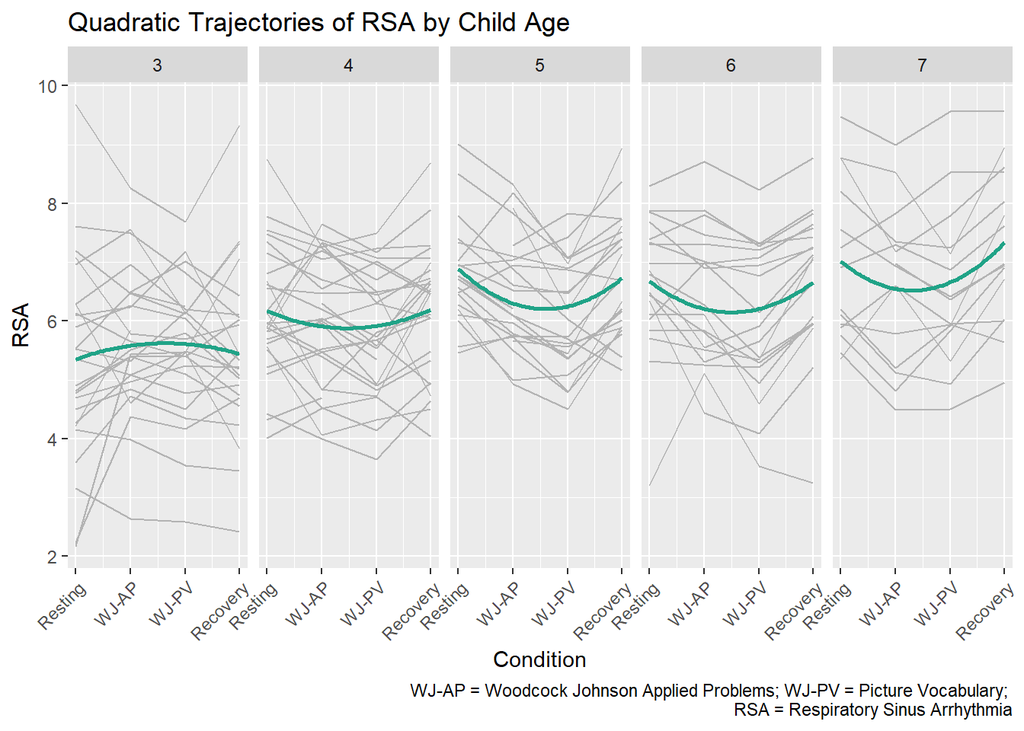

```r
p1 <- ggplot(data = d2, aes(x = Time, y = RSA)) +
    geom_line(aes(group = id), color = "gray70") +
    geom_smooth(method = "lm",
                formula = y ~ x + I(x^2),
                size = 1, se = FALSE,
                color = "#20A387FF") +
    facet_wrap(~W1TCAGEY, nrow = 1) +
    labs(title ="Quadratic Trajectories of RSA by Child Age",
         x = "Condition",
         caption = "WJ-AP = Woodcock Johnson Applied Problems; WJ-PV = Picture Vocabulary;
                    RSA = Respiratory Sinus Arrhythmia") +
    scale_x_continuous(name = "Condition",
                       limits = c(0, 3),
                       labels = c("Resting", "WJ-AP", "WJ-PV", "Recovery")) +
    theme(axis.text.x = element_text(angle = 45, hjust = 1))
p1
```

```r
#Looking for feedback on any changes that would reduce cognitive load required from x-axis labels
```

### Teresa’s attempt on plot 1

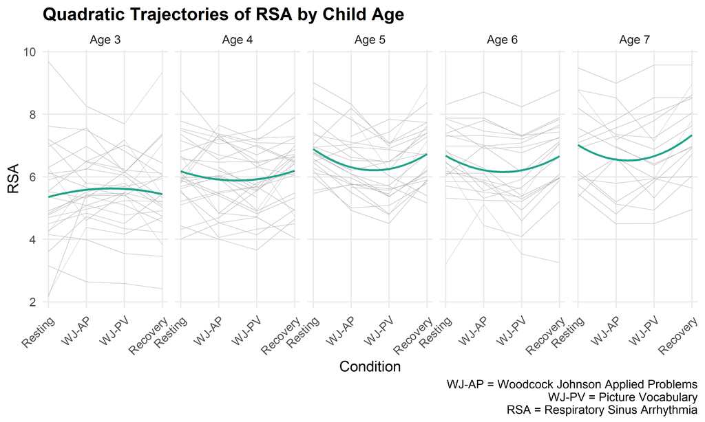

```r
d2 %>%
  filter(!is.na(RSA)) %>%
  mutate(Age = factor(W1TCAGEY, levels = c(3, 4, 5, 6, 7),
                           labels = c("Age 3", "Age 4", "Age 5", "Age 6", "Age 7"))) %>%
  # make age variable as factor with according labels
  ggplot(aes(x = Time, y = RSA)) +
  geom_line(aes(group = id),
            color = "gray70") +
  geom_smooth(method = "lm",
              formula = y ~ x + I(x^2),
              size = 2,
              se = FALSE,
              color = "#20A387FF") +
  facet_wrap(~Age,nrow = 1) +
  theme_minimal(base_size = 30) +
  scale_x_continuous(name = "Condition",
                     labels = c("Resting", "WJ-AP", "WJ-PV", "Recovery")) +
  labs(title ="Quadratic Trajectories of RSA by Child Age",
         x = "Condition",
         caption = "WJ-AP = Woodcock Johnson Applied Problems\n WJ-PV = Picture Vocabulary\n RSA = Respiratory Sinus Arrhythmia") +
  theme(axis.text.x = element_text(angle = 45, hjust = 1),
        panel.spacing = unit(1, "lines"), # increasing space between facets
        panel.grid.minor = element_blank(),
        plot.title = element_text(face = "bold")) # bold the title
```

### Visualization 2: For Teaching Purposes with Student Audience in a Multilevel Modeling Course

#### Visualizing uncertainty in growth curves as a way to demonstrate between-child variability and uncertainty in slope parameters

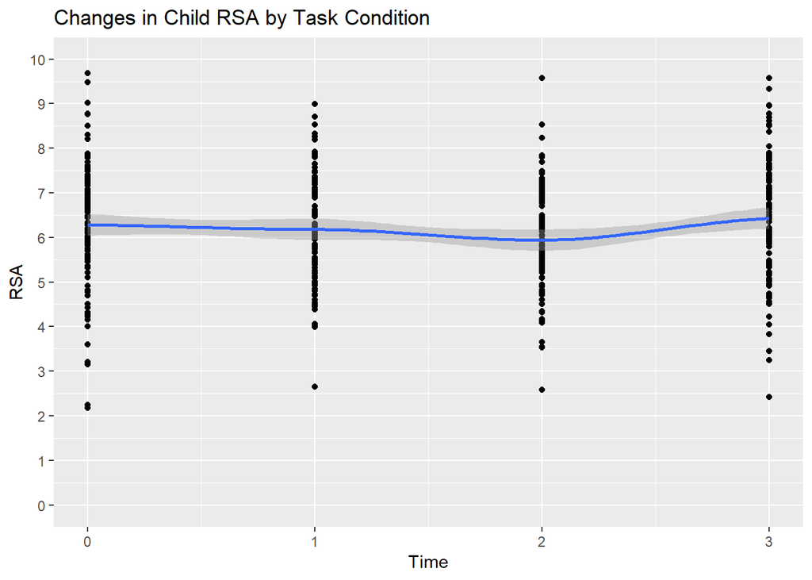

```r
#transform time to numeric
d2 <- d2 %>%
  mutate(Time = as.numeric(Time))

#first iteration
d2 %>%
  ggplot(aes(Time, RSA)) +
  geom_point() +
  geom_smooth() +
  scale_y_continuous(limits =c(0,10 ), breaks= seq(0, 10, by = 1)) +
  ggtitle( "Changes in Child RSA by Task Condition")
```

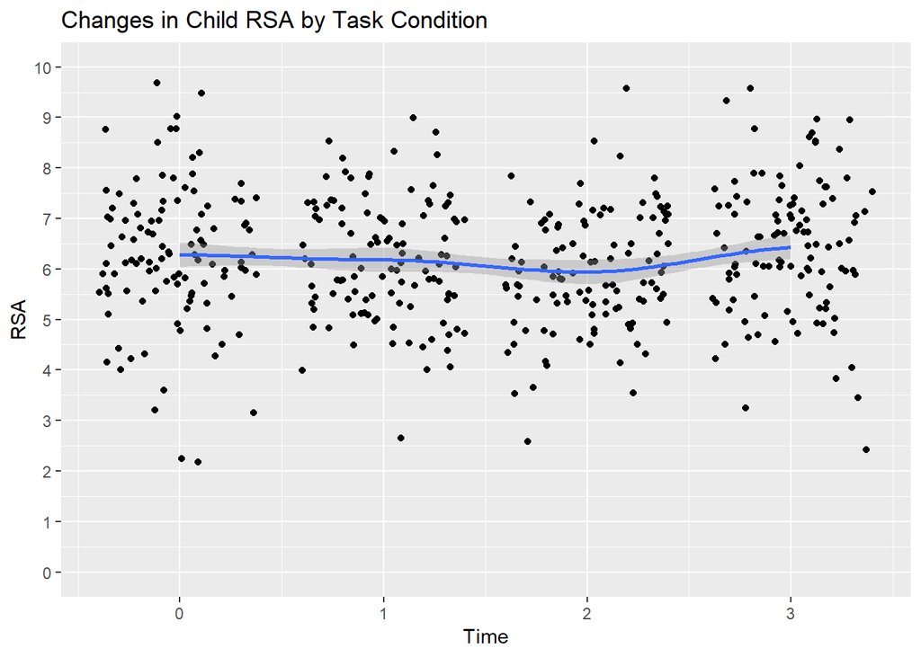

```r
#second iteration
#added jitter to points
#first iteration
d2 %>%
  ggplot(aes(Time, RSA)) +
  geom_point(position = "jitter") +
  geom_smooth() +
  scale_y_continuous(limits =c(0,10 ), breaks= seq(0, 10, by = 1)) +
  ggtitle( "Changes in Child RSA by Task Condition")
```

```r
#if reviewers have any suggestions about reducing the amount of jitter, it would be appreciated!
```

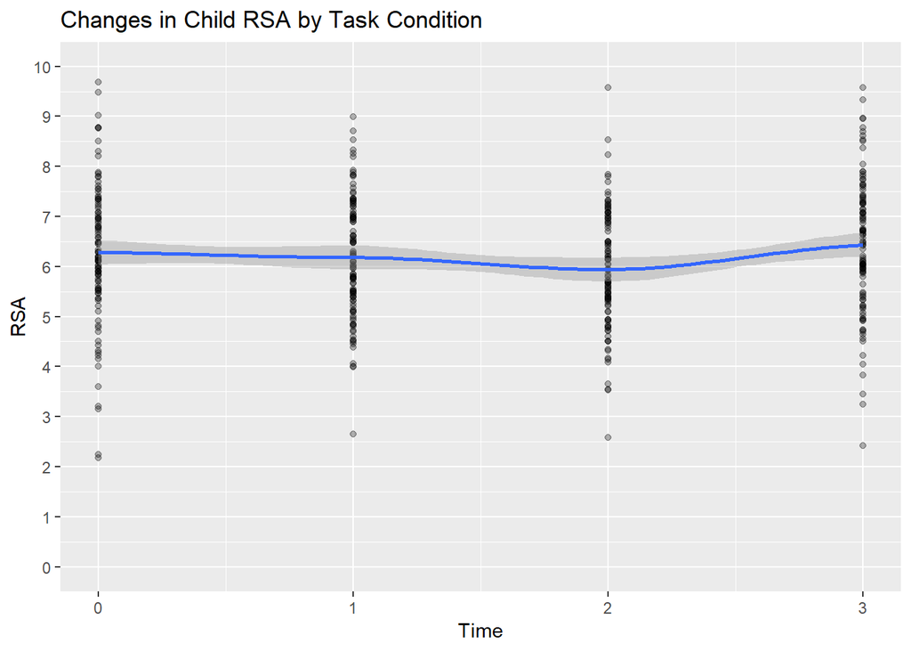

```r
#third iteration
#add tranparency to show overlapping points and removed jittering
d2 %>%
  ggplot(aes(Time, RSA)) +
  geom_point(alpha = .3) +
  geom_smooth() +
  scale_y_continuous(limits =c(0,10 ), breaks= seq(0, 10, by = 1)) +
  ggtitle( "Changes in Child RSA by Task Condition")
```

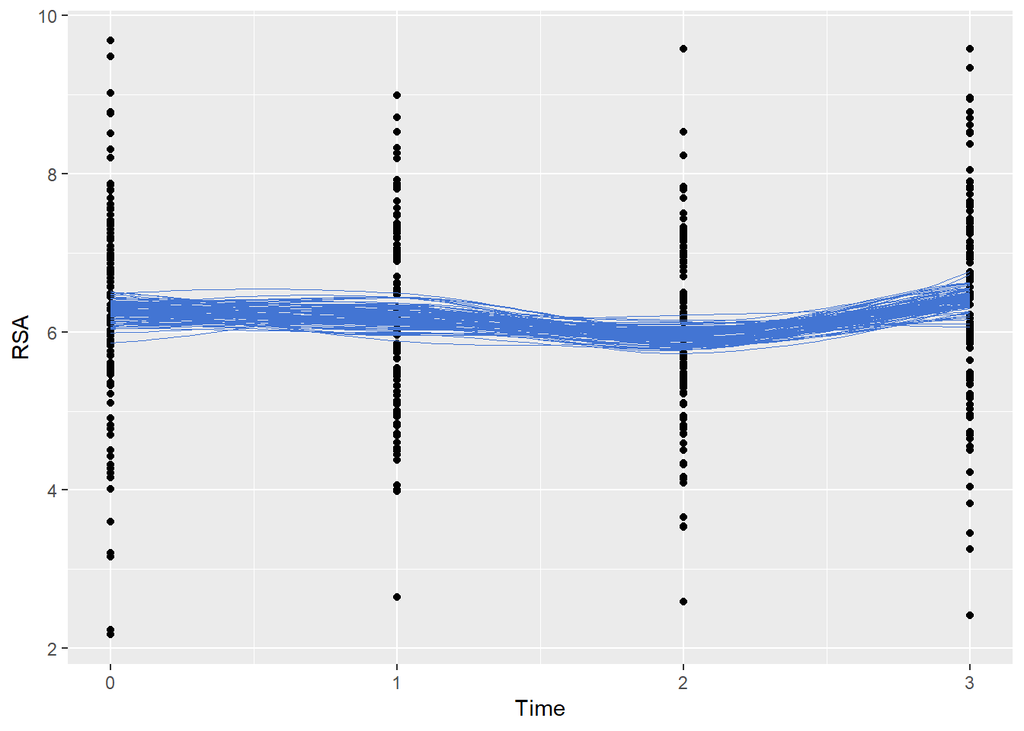

```r
#first use boostrapping to model variability
row_samps <- rerun(100,
      sample(seq_len(nrow(d2)),
             nrow(d2),
             replace = TRUE))


#extract samples
d_samps <- map_df(row_samps, ~d2[., ], .id = "sample")

#plotting both bootstrapped data
boots <- ggplot(d2, aes(Time, RSA)) +
  geom_point() +
  stat_smooth(aes(group = sample),
              data = d_samps,
              geom = "line",
              color = "#4375D3",
              fullrange = TRUE,
              size = 0.1)
boots
```

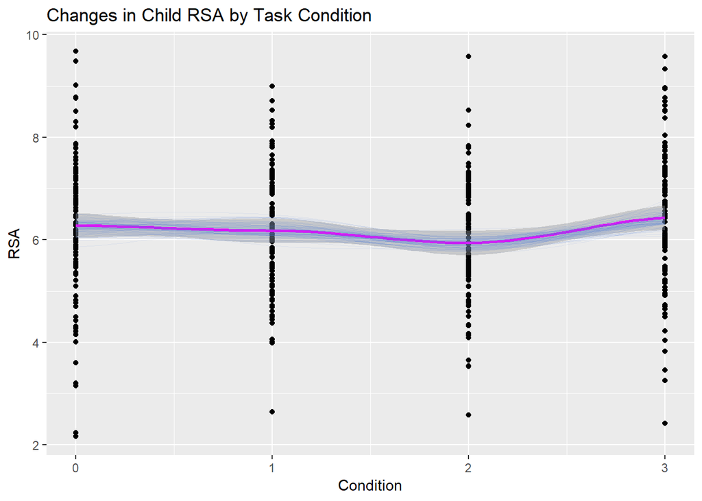

```r
#verify bootstrapped sample and raw data match
both <- ggplot(d2, aes(Time, RSA)) +
  geom_point() +
  geom_smooth(color = "magenta") +
  stat_smooth(aes(group = sample),
              data = d_samps,
              geom = "line",
              color = "#4375D3",
              fullrange = TRUE,
              size = 0.1,
              alpha = .1) +
  labs(title = "Changes in Child RSA by Task Condition",
       x = "Condition")
both
```

### Teresa’s attempt on plot 2

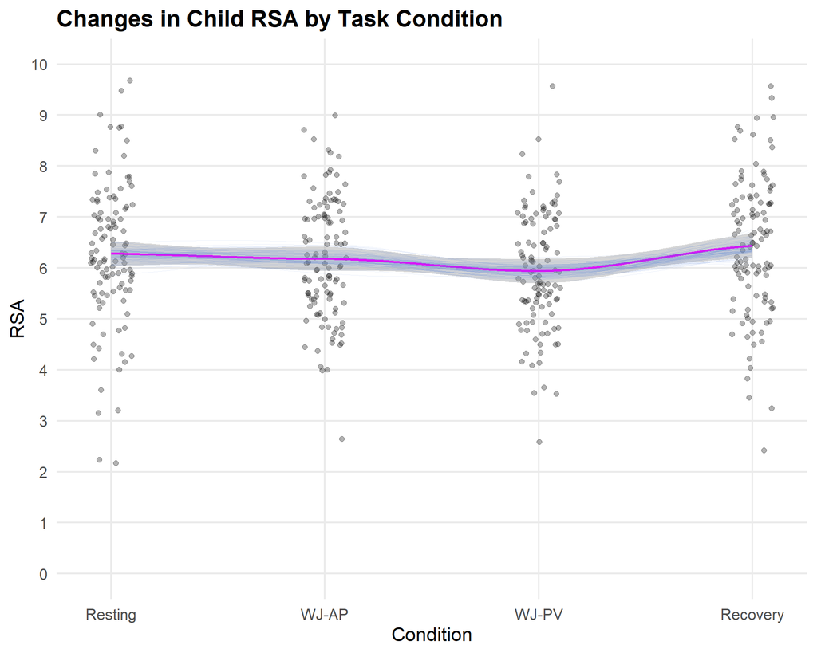

```r
d2 %>%
  filter(!is.na(RSA)) %>%
  ggplot(aes(x = Time, y = RSA)) +
  geom_jitter(alpha = 0.3,
              size = 2,
              width = 0.1) +  # change to small jitter width
  geom_smooth(color = "magenta") +
  stat_smooth(aes(group = sample),
              data = d_samps,
              geom = "line",
              color = "#4375D3",
              fullrange = TRUE,
              size = 0.1,
              alpha = .1) +
  scale_y_continuous(limits =c(0,10 ),
                     breaks= seq(0, 10, by = 1)) +
  scale_x_continuous(name = "Condition",
                     labels = c("Resting", "WJ-AP", "WJ-PV", "Recovery")) +
  labs(title =  "Changes in Child RSA by Task Condition") +
  theme_minimal(base_size = 17) +
  theme(panel.grid.minor = element_blank(),
        plot.title = element_text(face = "bold"))
```

###Final animated plot

####I set this to eval = FALSE as I am not able to successfully get it to render.

```r
#install.packages("gganimate") install gganimate if needed
#install.packages("gifski") install gifski package to render animation


library(gganimate)
library(gifski)
ggplot(d2, aes(Time, RSA)) +
  geom_point(alpha = .1) +
  stat_smooth(data = filter(d_samps, sample <= 20), # Only animate first 20
              geom = "line",
              color = "#4375D3",
              fullrange = TRUE) +
  transition_states(sample,
                    transition_length = 0.5,
                    state_length = 0.5) +
  ease_aes('linear') +
  labs(title = "Changes in Child RSA by Task Condition",
       x = "Condition")


#anim_save(here::here("edled610_msc_final", "data", "RSA_hop.gif")) #trying to save animation
#![](final/RSA_hop.gif)

#Reviewers: I am struggling to get my visualization to save as a .gif to animate it. I also need to consider replicability, for example, where do I set the animation to save so anyone could access it?
```

### Teresa’s try on plot 2 (animation)

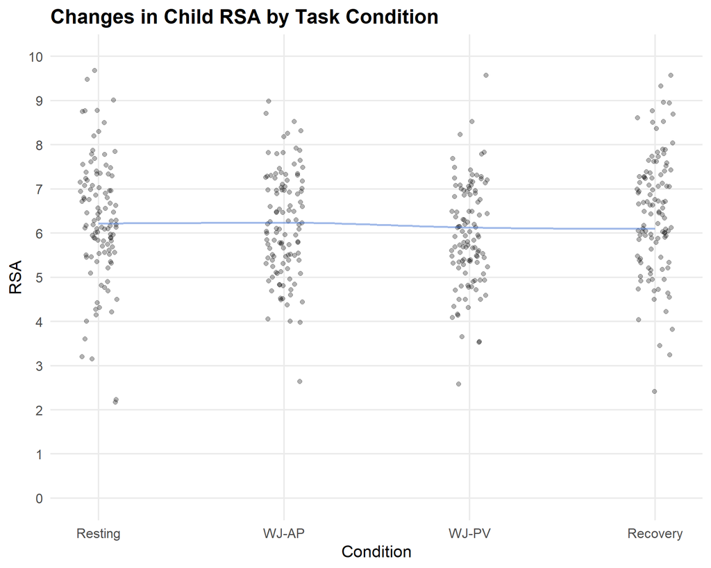

```r
ani_plot2 <- d2 %>%
  filter(!is.na(RSA)) %>%
  ggplot(aes(Time, RSA)) +
  geom_jitter(alpha = 0.3,
              size = 2,
              width = 0.1) +  # change to small jitter width
  stat_smooth(data = filter(d_samps, sample <= 20),
              geom = "line",
              color = "#4375D3",
              fullrange = TRUE,
              size = 1,
              alpha = 0.5) +
  scale_y_continuous(limits =c(0, 10),
                     breaks= seq(0, 10, by = 1)) +
  scale_x_continuous(name = "Condition",
                     labels = c("Resting", "WJ-AP", "WJ-PV", "Recovery")) +
  labs(title =  "Changes in Child RSA by Task Condition") +
  theme_minimal(base_size = 17) +
  theme(panel.grid.minor = element_blank(),
        plot.title = element_text(face = "bold")) +
  transition_states(sample,
                    transition_length = 0.5,
                    state_length = 0.5) +
  ease_aes('linear')

ani_plot2
```

```r
anim_save(filename = "data/ani_plot2.gif") # save .gif to data folder
```

### Third Visualization for Community Audience

#### Visualizing levels of adversity, as measured by ACE exposure, by child age and gender for hypothetical audience of clinicians who would like to better characterize the population they support.

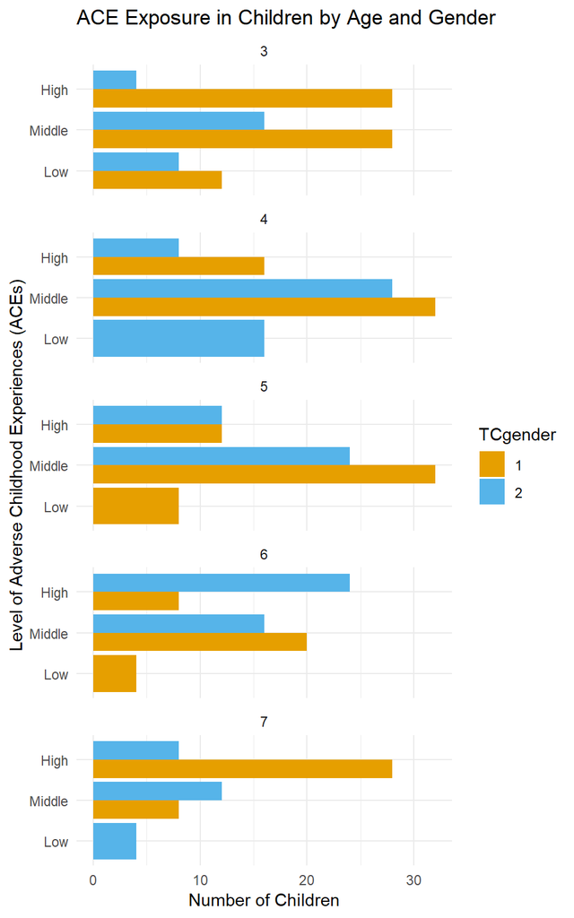

```r
#turn gender into a factor
d2 <- d2 %>%
  mutate(TCgender = as.factor(TCgender))

#creating categorical variable based on Adverse Childhood Life Experiences. I am taking a continuous measure that ranges 0 - 10 and grouping it into "low", "medium", and "high."

d2$category <- cut(d2$PEXCTOT1,
                   breaks=c(-Inf, 1, 4, Inf),
                   labels=c("Low","Middle","High"))

# removing NAs from ACE exposure variable
d2 <- d2 %>%
  filter(category != "na")


#third visualization
viz3 <- ggplot(d2, aes(category)) +
  geom_bar(aes(fill = TCgender), position = "dodge") +
  facet_wrap(~W1TCAGEY, nrow = 5) +
  coord_flip() +
  scale_fill_OkabeIto() +
  theme_minimal() +
  labs(title = "ACE Exposure in Children by Age and Gender",
       x = "Level of Adverse Childhood Experiences (ACEs)",
       y = "Number of Children")

viz3
```

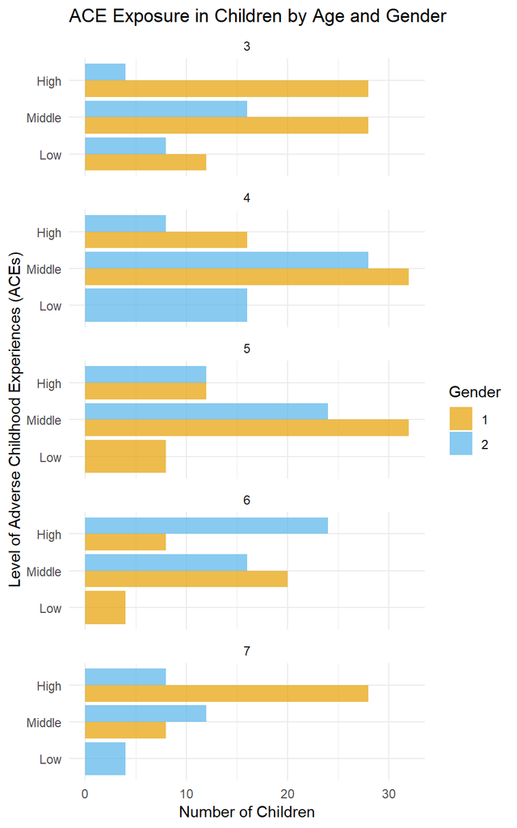

```r
#rename Gender factor levels
#library(plyr)
d2 <- d2 %>%
  mutate(TCgender = as.factor(TCgender))


#putting some transparency in bars with alpha;
viz3 <- ggplot(d2, aes(category)) +
  geom_bar(aes(fill = TCgender), position = "dodge", alpha = 0.7) +
  facet_wrap(~W1TCAGEY, nrow = 5) +
  coord_flip() +
  scale_fill_OkabeIto() +
  theme_minimal() +
  labs(title = "ACE Exposure in Children by Age and Gender",
       x = "Level of Adverse Childhood Experiences (ACEs)",
       y = "Number of Children",
       fill = "Gender") # 1 = boy, 2 = girl

viz3
```

```r
#need to add fct_reorder
#Consider annotating Gender
#Or, change values of Gender facotr
#d2<- d2 %>%
#  revalue(TCgender, c("1"="boy", "2"="girl"))
#I can't figure out how to get the low category to only reflect one gender when there is a NA value (e.g., for 7-year-olds there are only girls who are in the low ACE category)
```

### Teresa’s attempt on plot 3

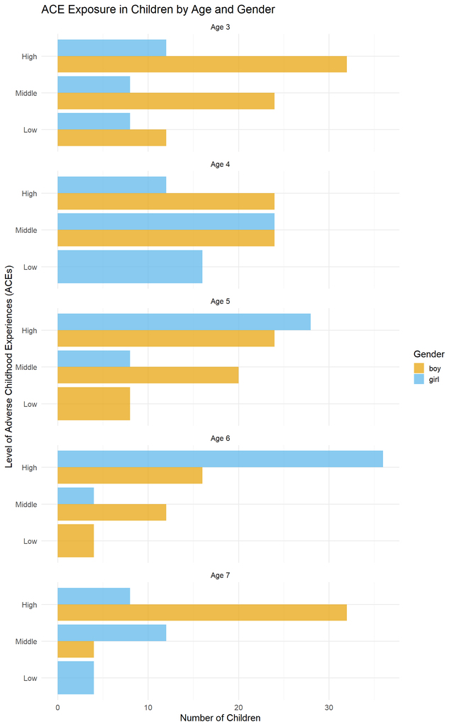

```r
d2 %>%
  mutate(Gender = factor(TCgender, levels = c(1, 2),
                         labels = c("boy", "girl")),
         # here I change gender to factor with according labels
         Age = factor(W1TCAGEY, levels = c(3, 4, 5, 6, 7),
                           labels = c("Age 3", "Age 4", "Age 5", "Age 6", "Age 7")),
         Category = dplyr::case_when(
           PEXCTOT1 >= 4 ~ "High",
           PEXCTOT1 > 1 & PEXCTOT1 < 4 ~ "Middle",
           PEXCTOT1 <= 1 ~ "Low",
           TRUE ~ "NA"
         )) %>%
  # I'm not sure about how to categorize 1 and 4, I assume they are "middle" and "low" respectively. Using case_when instead of cut can make coding more efficient.
  filter(Category != "NA") %>%
    ggplot(aes(factor(Category, levels = c("Low", "Middle", "High")))) +
      geom_bar(aes(fill = Gender), position = "dodge", alpha = 0.7) +
      facet_wrap(~Age, nrow = 5) +
      coord_flip() +
      scale_fill_OkabeIto() +
      theme_minimal(base_size = 15) +
      labs(title = "ACE Exposure in Children by Age and Gender",
           x = "Level of Adverse Childhood Experiences (ACEs)",
           y = "Number of Children",
           fill = "Gender")
```